# Making Interactive Maps With Sociomepy

Sociomepy is a Python package that provides a number of convenient functions, data structures, and models for manipulating socio-environmental data. Implementation-wise it is a wrapper around the GeoPandas library and is fully compatible with all data formats that geopandas accepts.

This notebook produces an interactive map of the City of Chicago that illustrates some of the initial data that the project has curated.

## Loading Addresses

First, we will get a baseline set of addresses in the city of chicago so can establish regional boundaries.

```python
from sociomepy.data import SociomeDataFrame
from sociomepy.accessors import access_by_attribute
chicago = SociomeDataFrame.from_csv('http://chicago-exposures.s3.amazonaws.com/chicago-assessments.csv', access_by_attribute('Longitude', 'Latitude'))
```

## Adding Metrics To Dataset

Next, we will add a number of important metrics of interest to the data.

```python
acs = SociomeDataFrame.from_zip_file('http://chicago-geospatial.s3.amazonaws.com/chicago-acs.zip')
chicago.add_subdivision(acs, 'tract', 'GEOID')
```

```
<sociomepy.data.SociomeDataFrame at 0x11e81a790>
```

### ACS Income

Let's add median household income to this dataset.

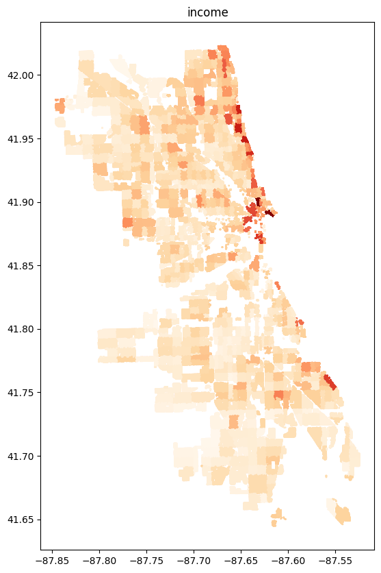

```python
from sociomepy.metrics import SpatialSubdivisionFunction

income = SpatialSubdivisionFunction(acs, 'tract', 'SE_A1006_2', 'GEOID')
chicago.add_metric_to_data(income, income')
chicago.to_mpl_inline(['income'])
```

### ChiVes Data

Now, we will integrate data from the ChiVes Chicago Dataset. This gives us some of the Census Tract Level Asthma numbers based on Chives survey data.

```python
chicago_chives = SociomeDataFrame.from_csv('http://chicago-exposures.s3.amazonaws.com/chicago-chives.csv', access_by_attribute('intptlon', 'intptlat'))
```

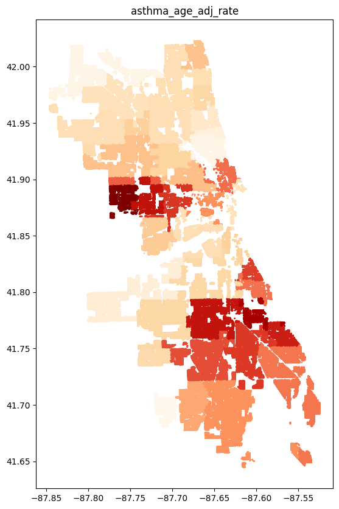

```python
chicago_chives.data['geoid'] =  chicago_chives.data['geoid'].apply(lambda x: str(x)) #will be fixed in an updated version of the dataset
asthma = SpatialSubdivisionFunction(chicago_chives, 'tract', 'asthma_age_adj_rate', 'geoid')
chicago.add_metric_to_data(asthma, 'asthma_age_adj_rate')
chicago.to_mpl_inline(['asthma_age_adj_rate'])
```

Next, we will add some information about pollutants

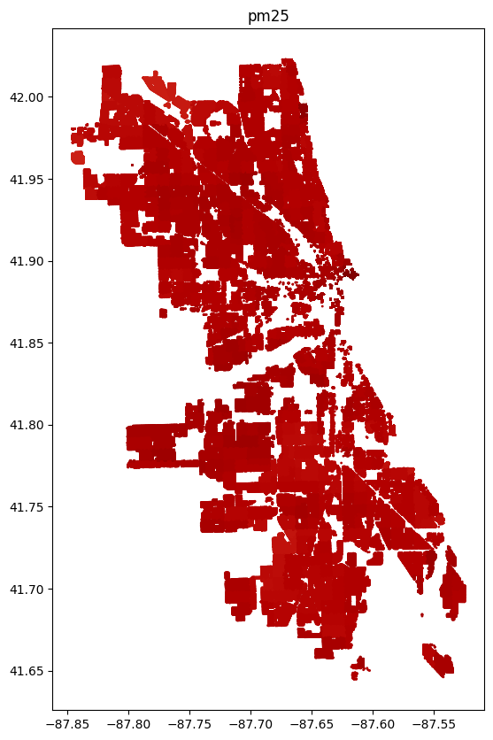

```python
chicago_chives.data['geoid'] =  chicago_chives.data['geoid'].apply(lambda x: str(x)) #will be fixed in an updated version of the dataset
asthma = SpatialSubdivisionFunction(chicago_chives, 'tract', 'nn_q3_pm2_5', 'geoid')
chicago.add_metric_to_data(asthma, 'pm25')
chicago.to_mpl_inline(['pm25'])
```

### Housing Assessments

Using property tax assessment data, we can also identify materials and structures used in each house.

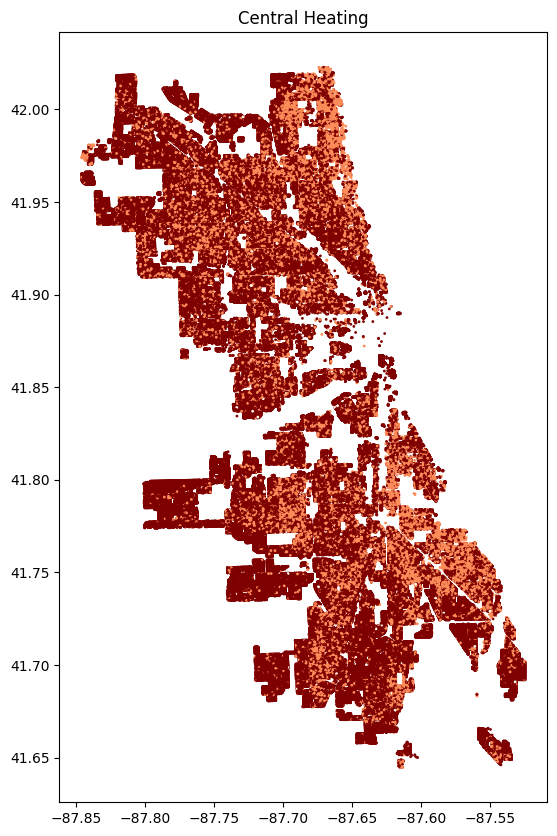

```python
chicago.to_mpl_inline(['Central Heating'])
```

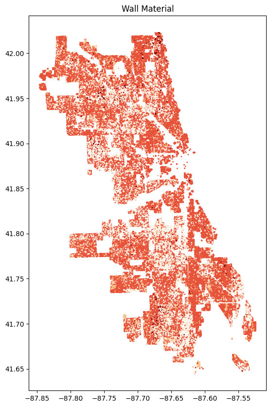

```python
chicago.to_mpl_inline(['Wall Material'])
```

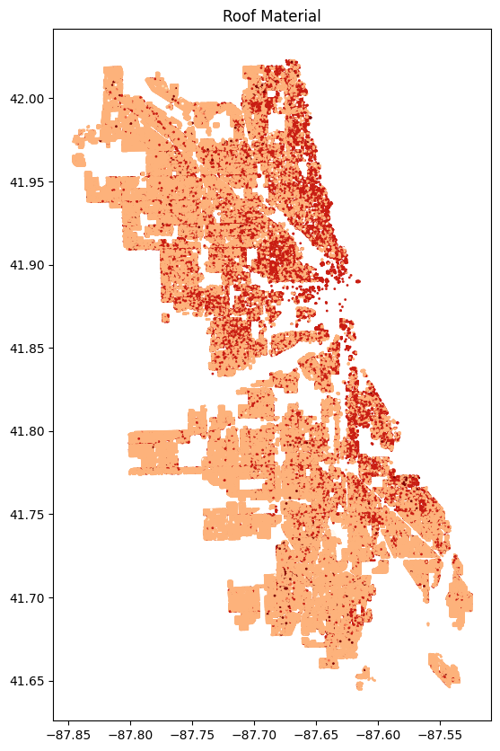

```python
chicago.to_mpl_inline(['Roof Material'])
```

## Exporting the Map

Next, we will export this map to create an interactive dialog. We will create aa 5% of addresses.

```python
chicago.to_kepler_html('demo.html', ['Property Address', 'Roof Material', 'Wall Material', 'pm25', 'asthma_age_adj_rate', 'income'], sampling_rate=0.05)
```

```
User Guide: https://docs.kepler.gl/docs/keplergl-jupyter
```

```
Map saved to demo.html!
```